# Midterm: In-Class

Complete this exam in a .Rmd file. To turn in the exam, push both a .Rmd file and a knitted .html file to your GitHub site.

Statement of Integrity: “All work presented is my own. I have not communicated with or worked with anyone else on this exam.” Jessica Tom

Collaboration Reminder: You may not communicate with or work with anyone else on this exam, but you may use any of our course materials or materials on the Internet.

Question 1 (20 points). Examine the following plot that uses the pokemon_full.csv data set. The plot gives the count of each Pokemon type.

```r
library(tidyverse)
library(here)
pokemon_df <- read_csv(here("data/pokemon_full.csv"))
```

```
## * `` -> ...1
```

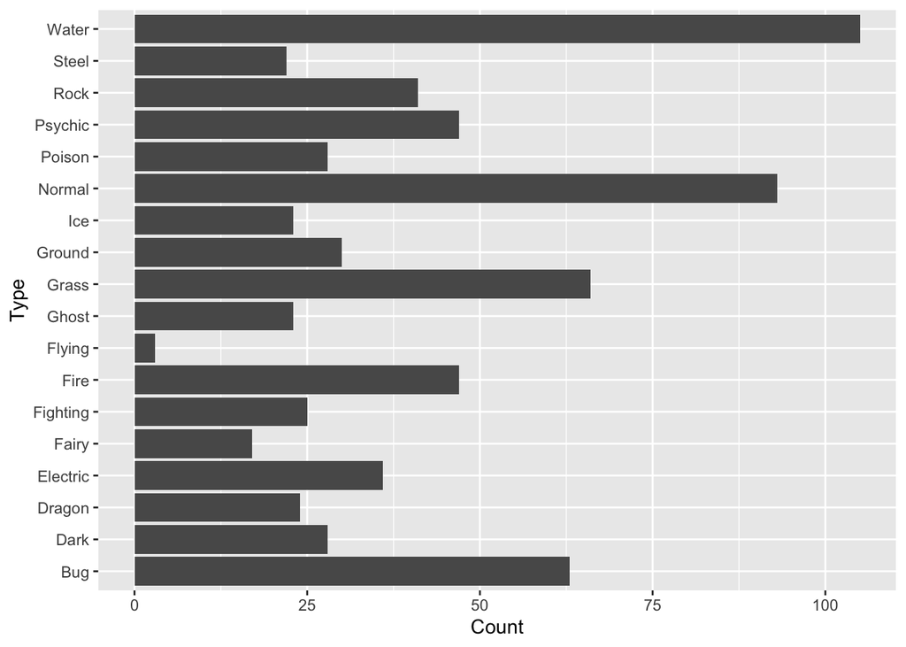

```r
pokemon_type <- pokemon_df %>% group_by(Type) %>% summarise(type_count = n())

ggplot(data = pokemon_type, aes(x = Type, y = type_count)) +
  geom_bar(stat = "identity") +
  labs(x = "Type",
       y = "Count") +
  coord_flip()
```

part a. Which of the 7 grammar of graphics parameters are explicitly specified in the code to make the plot? DATA, GEOM FUNCTION, MAPPING, STAT, COORDINATE FUNCTION

part b. For these types of plots, we have usually reordered the Type so that the type with the most Pokemon would be first and the type with the least number of pokemon would be last. Use a principle from the Data Visualization Reading to explain why we would want to do this. Because of the psychology of data visualization (relative position in this case), we need to present the data as understandable as possible for the audience. By ordering the data, the viewer has an easier time perceiving and interpretating the data.

part c. We have also stated that, for bar plots and lollipop plots, 0 should be included in the plot. On the other hand, for point plots and scatterplots, 0 need not be included. Using a principle from the Data Visualization Reading, explain why it is okay to omit 0 from a point plot but not from a bar plot. Bar plots show the “variables as lengths,” so each length of the bar plot above represents the number of pokemon for each type. It is in this way that importance of starting from 0 is defined, aiding the audience in their interpretation of the graph. On the other hand, the points do not account for the variables as lengths, so it is okay to not start from zero, as it does not need to visually show the length of the variable.

Question 2 (5 points). These points will be given for properly committing and pushing a .Rmd and a .html file with your exam answers.

Question 3 (5 points). Tell me something you learned about ethics in data visualization. I learned that when dealing with sensitive data, such as murders or assaults among a particular group of people, it is ethical to humanize the data. Because data can sometimes come across as only numbers, it is important to remind the audience that the information comes from real people.

Question 4 (20 points).

part a. A data set on United States election results was obtained from https://github.com/kjhealy/us_elections_2020_csv. Use the maps package, as well as this data set (posted on Sakai), to construct a map that fills each U.S. State with the percent of voters who voted for the republican candidate, Trump (percent_gop). For this problem,

you do not need to worry about including Alaska or Hawaii. They are important but this is a timed exam! you should change the colour scale so that it is appropriate for the problem.

```r
library(maps)
library(tidyverse)
library(here)
election_df <- read_csv(here("data/2020_county_pres.csv")) %>%
  group_by(state_name) %>%
  summarise(total_gop = sum(votes_gop),
            total_dem = sum(votes_dem)) %>%
  mutate(percent_gop = 100 * total_gop / (total_gop + total_dem)) %>%
  mutate(state_name = str_to_lower(state_name))
state_df <- ggplot2::map_data("state")
view(state_df)
state_df %>% row()
```

[output not shown]

[output cut: 15523 more lines]

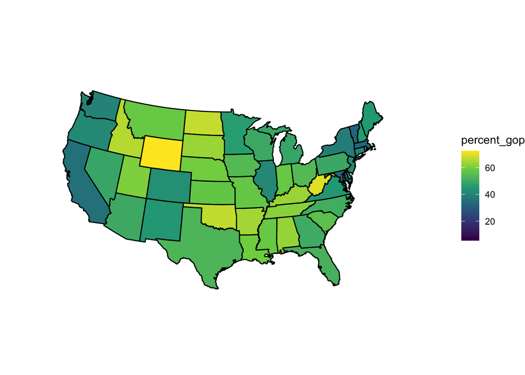

```r
state_elections <- left_join(state_df, election_df, by = c("region" = "state_name"))
ggplot(data = state_elections, aes(x = long, y = lat, group = group)) +
  geom_polygon(colour = "black", aes(fill = percent_gop)) +
  coord_map(projection = "albers", lat0 = 39, lat1 = 45) +
  theme_void() +
  scale_fill_viridis_c()
```

part b. Explain why the data frame R needs to construct a map of the United States is much, much longer than 50 rows.

The data frame is much longer than 50 rows because it needs to account for all the coordinates, which need more than just the 50 coordinates, in order to create the shape of the map.

Question 5 (25 points). Construct a shiny app using the alcohol.csv data set that has a scatterplot of the number of wine servings vs. the number of beer servings. In the app, the user should be able to select a country and have a label for that country appear on the app.

In addition, create an input that lets the user choose a variable (either beer_servings, spirit_servings, and wine_servings) and create an output that is a histogram based on that variable.

So you can focus your time on shiny as much as possible, a static graph or wine servings vs. beer servings, with Australia labeled, is given below (you may copy this code to use in your app if you would like).

You must complete this task using shiny (even though you could do something similar using plotly).

```r
library(shiny)
library(tidyverse)
library(ggrepel)
library(here)
alcohol_df <- read_csv(here("data/alcohol.csv"))
```

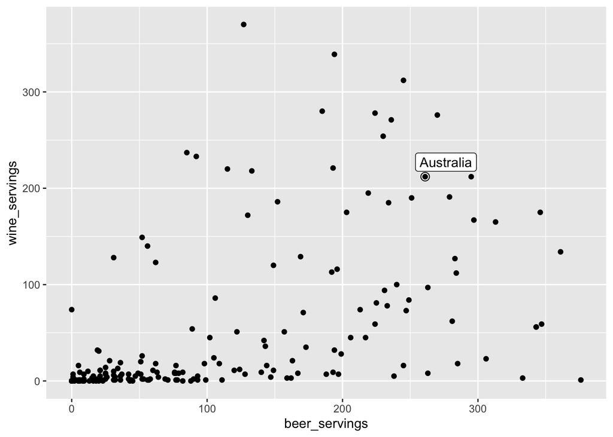

```r
onecountry_df <- alcohol_df %>% filter(country == "Australia")

ggplot(alcohol_df, aes(x = beer_servings, y = wine_servings)) +
  geom_point() +
  geom_label_repel(data = onecountry_df, aes(label = country)) +
  geom_point(data = onecountry_df, size = 3, shape = 1)
```

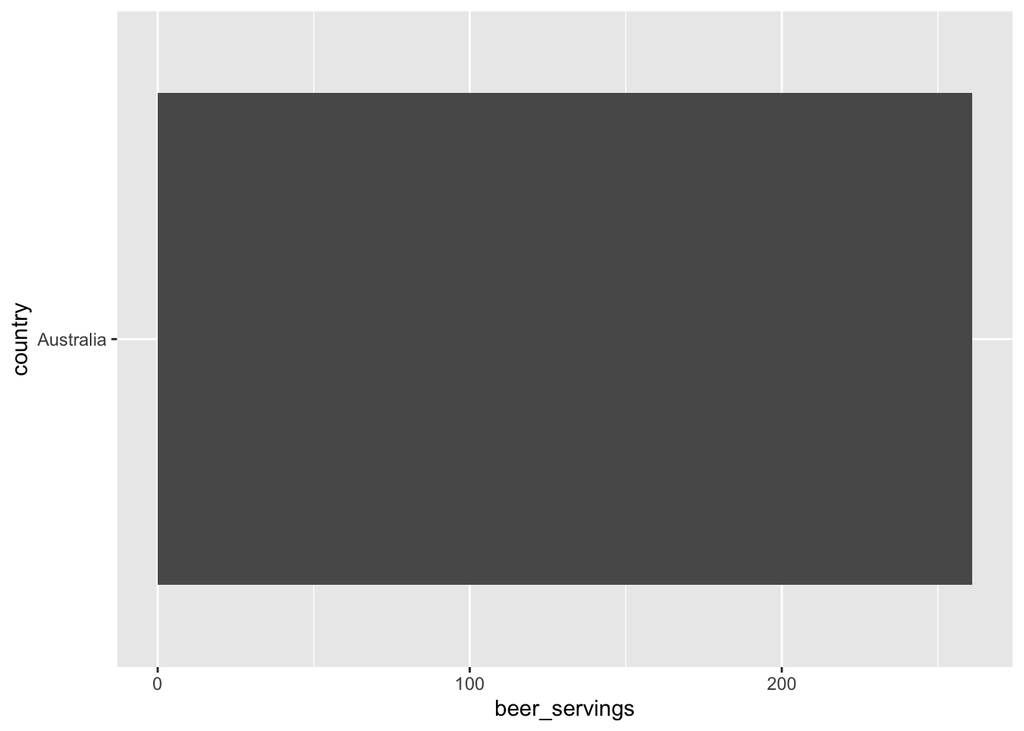

```r
ggplot(onecountry_df, aes(x = country, beer_servings)) +
  geom_col() +
  coord_flip()
```

```r
var_choices <- names(alcohol_df)[2:4]
var_choices
```

```
## [1] "beer_servings"   "spirit_servings" "wine_servings"
```

```r
ui <- fluidPage(
  sidebarLayout(
    sidebarPanel(selectizeInput(inputId = "regionchoice",
                                label = "Choose a Country",
                                choices = factor(alcohol_df$country),
                                selected = "Australia"),
                 radioButtons(inputId = "varschoice",
                              label = "Choose a Variable",
                              choices = var_choices)
                 ),
    mainPanel(plotOutput("scatterplot",
                         "histogram"))
))
```

```
## Error in validateCssUnit(width): "histogram" is not a valid CSS unit (e.g., "100%", "400px", "auto")
```

```r
server <- function(input, output, session) {
  onecountry_df <- reactive({
    alcohol_df %>% filter(country == input$country)
  })

  scatter <- reactive({
    ggplot(alcohol_df, aes(x = beer_servings, y = wine_servings)) +
      geom_point() +
      geom_label_repel(data = onecountry_df(), aes(label = .data[[input$country]])) +
      geom_point(data = onecountry_df(), size = 3, shape = 1)
  })

  histograph <- reactive({
    ggplot(onecountry_df(), aes(x = .data[[input$country]], y = .data[[input$vars_choice]])) +
      geom_col() +
      coord_flip()
  })

  output$scatterplot <- renderPlot({
    scatter()
  })

  output$histogram <- plotOutput({
    histograph()
  })
}

shinyApp(ui, server)
```

```
## Error in force(ui): object 'ui' not found
```

Question 6 (10 points). For the following shiny app, draw a reactive graph. I think the easiest way to do this would be to hand-draw the graph and hand it in on a piece of paper (there is paper at the front of the room). If you can figure out a way to draw it on your computer, you may do that and push that file to GitHub.

```r
ui <- fluidPage(
  radioButtons("input1"),
  selectInput("input2"),
  numericInput("input3"),
  plotOutput("output1"),
  tableOutput("output2")
)
```

```
## Error in normalizeChoicesArgs(choices, choiceNames, choiceValues): Please specify a non-empty vector for `choices` (or, alternatively, for both `choiceNames` AND `choiceValues`).
```

```r
server <- function(input, output, session) {

  df <- tibble(xvar = c(1, 2, 3), yvar = c("a", "b", "c"))

  newval <- reactive({
    input$input1 - input$input2
  })

  anotherval <- reactive({
    log(input$input1)
  })

  output$output1 <- renderPlot({
    plot(newval())
  })

  output$output2 <- renderTable({
    table(df[[input$input3]])
  })
}

shinyApp(ui, server)
```

```
## Error in force(ui): object 'ui' not found
```

Question 7 (20 points). Consider again the women’s tennis data set, wta_matches_2019.csv, where each row corresponds to a match played on the WTA (Women’s Tennis Association) tour. Important variables to consider for this problem include:

winner_name, the name of the player who won the match loser_name, the name of the player who lost the match Construct a lollipop chart that shows the 10 WTA tennis players with the highest average number of aces in the 2019 season who have played at least 20 matches.

Some Hints:

if you can’t complete the task, make a lollipop chart of something to earn some partial credit. variables that you will need are winner_name, loser_name, w_ace, and l_ace. we haven’t done much in tidyr in class so I’ve already pivoted the data set for you (see code below). you will need to create a new variable called aces that is the w_ace if the player won (so if won_or_lost is winner_name) and l_ace if the player lost. recall that, if there are missing values, you will need to remove them when finding the mean aces for a player. You can do this with the na.rm = TRUE argument to your summarise() function. See https://highamm.github.io/datascience234/dplyr.html#removing-missing-values for a quick review of this. you will also need to count up the matches for each player and use a filtering join to only keep players who have played 20 or matches. As I’m writing this, I am realizing we did not do a ton with joins….so here is some code that may be helpful: semi_join(data_set_with_players_and_mean_aces, data_set_with_players_with_20_matches_or_more, by = c(“player” = “player”))

```r
library(tidyverse)
library(here)
wta_df <- read_csv(here("data/wta_matches_2019.csv"))
```

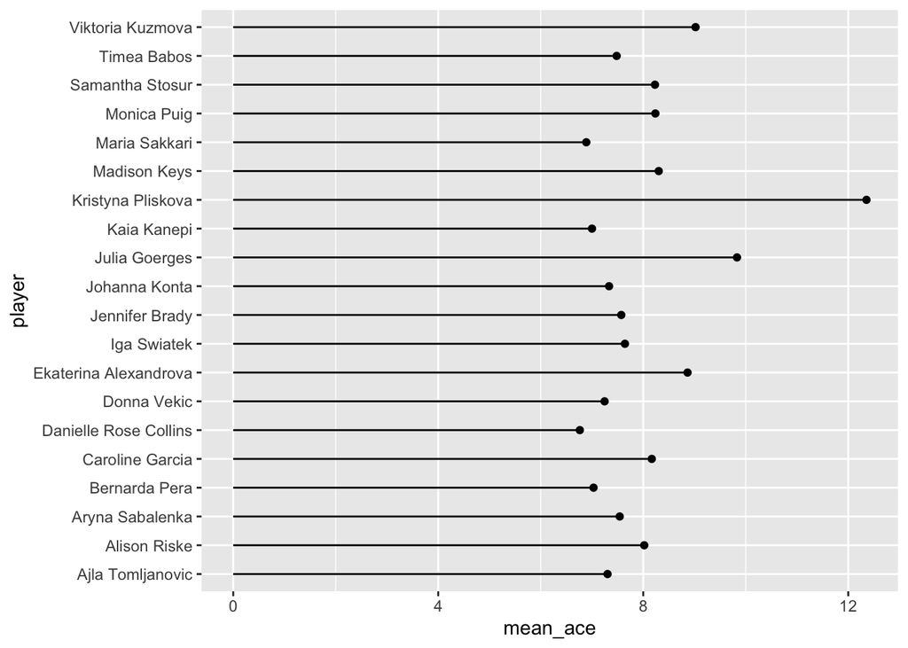

```r
wta_long <- wta_df %>% pivot_longer(c(winner_name, loser_name),
                                    names_to = "won_or_lost",
                                    values_to = "player") %>%
  select(won_or_lost, player, everything())

wta <- wta_long %>% mutate(aces = case_when(won_or_lost == "winner_name" ~ "w_ace",
                                     won_or_lost == "loster_name" ~ "l_ace")) %>%
  mutate(n_ace = w_ace + l_ace)

wta_ace <- wta %>%
  group_by(player) %>%
  summarise(mean_ace = mean(n_ace), na.rm = TRUE)
wta_filter <- wta_long %>% group_by(player) %>%
  summarise(n_matches = n()) %>% filter(n_matches >= 20)
wta_20 <- semi_join(wta_ace, wta_filter, by = c("player" = "player")) %>%
  arrange(desc(mean_ace)) %>%
  slice(1:20)

ggplot(data = wta_20, aes(x = player, y = mean_ace)) +
  geom_segment(aes(x=player,
                   xend=player,
                   y=0,
                   yend=mean_ace)) +
  geom_point() +
  coord_flip()
```

Question 8 (20 points).

part b. Fix the plot so that it no longer has the issue you described in Question 8a. If you could not make the plot in Question 7, use this much simpler data set to plot the mean of yvar for each group and then fix the issue.

```r
library(tibble)
set.seed(03092022)
toy_df <- tibble(group = c("a", "a", "a", "b", "b", "b", "c", "c",
                           "c", "c", "d", "d"),
       response = rnorm(12, 4, 3))

ggplot(data = wta, aes(x = n_ace, y = player)) +
  geom_point(alpha = 0.4) +
  geom_point(data = wta_mean,
             aes(x = mean_ace, colour = "Mean Aces")) +
  scale_colour_manual(values = c("Mean Aces" = "red"))
```

[output not shown]

```
## Error in fortify(data): object 'wta_mean' not found
```